# hw1_Hu

Die Hu

1/28/2021

```r
library(reshape)
library(ggplot2)
```

### Question 1

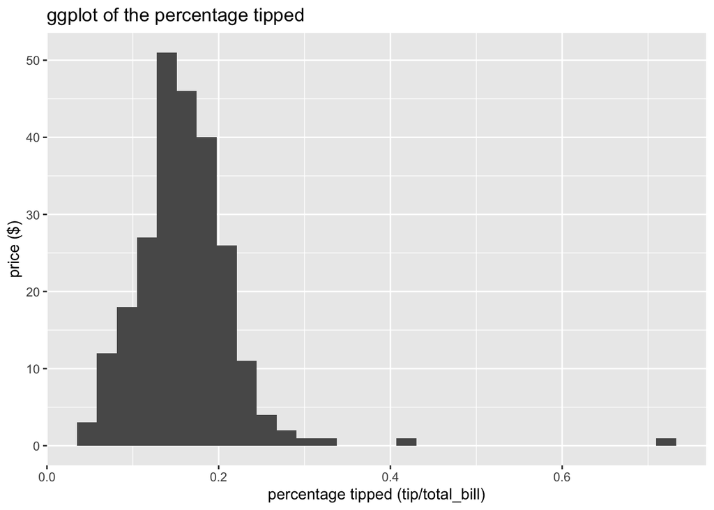

```r
data(tips)
ggplot(tips, aes(x = tip/total_bill)) + geom_histogram()+
    xlab("percentage tipped (tip/total_bill)") +
    ylab("price ($)") +
        ggtitle("ggplot of the percentage tipped")
```

```r
mean(tips$tip/tips$total_bill)
```

```
## [1] 0.1608026
```

### Question 2

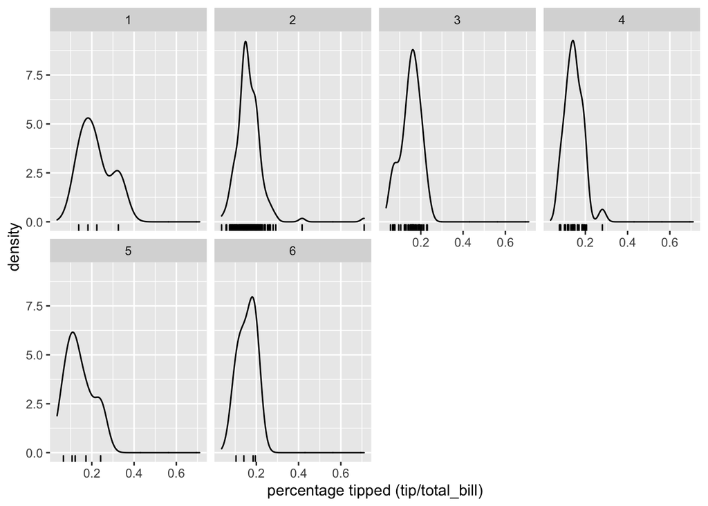

```r
ggplot(tips, aes(x = tip/total_bill)) +
    geom_density() +  geom_rug() +
    facet_wrap(~ size, ncol = 4) + xlab("percentage tipped (tip/total_bill)")
```

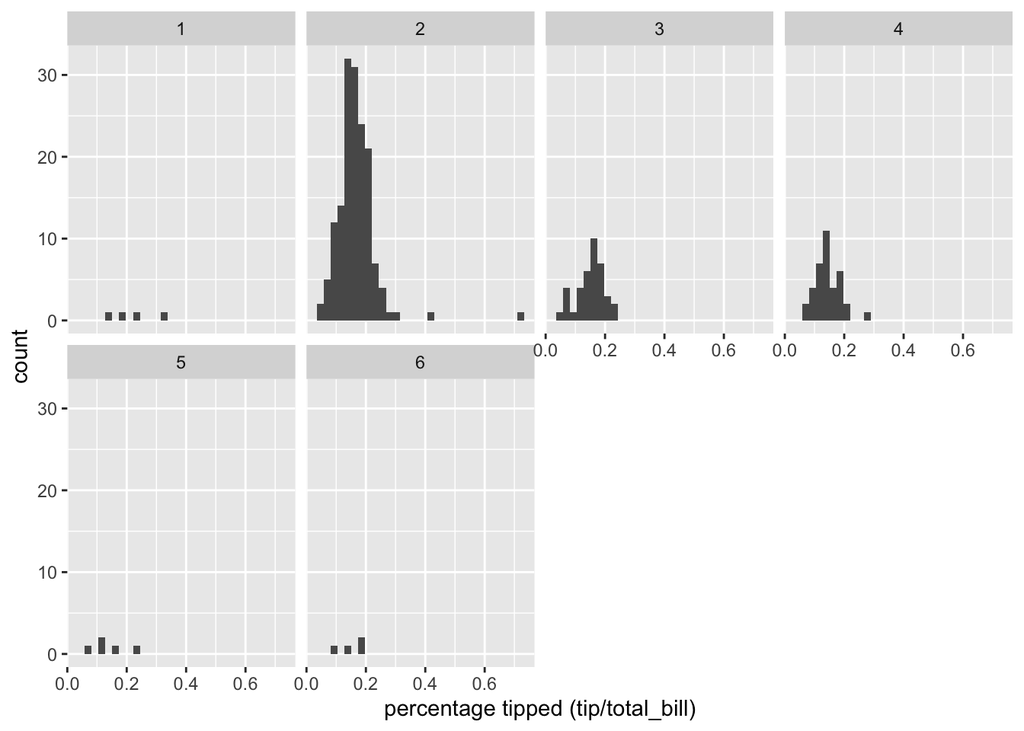

```r
ggplot(tips, aes(x = tip/total_bill)) +
    geom_histogram() +
    facet_wrap(~ size, ncol = 4) + xlab("percentage tipped (tip/total_bill)")
```

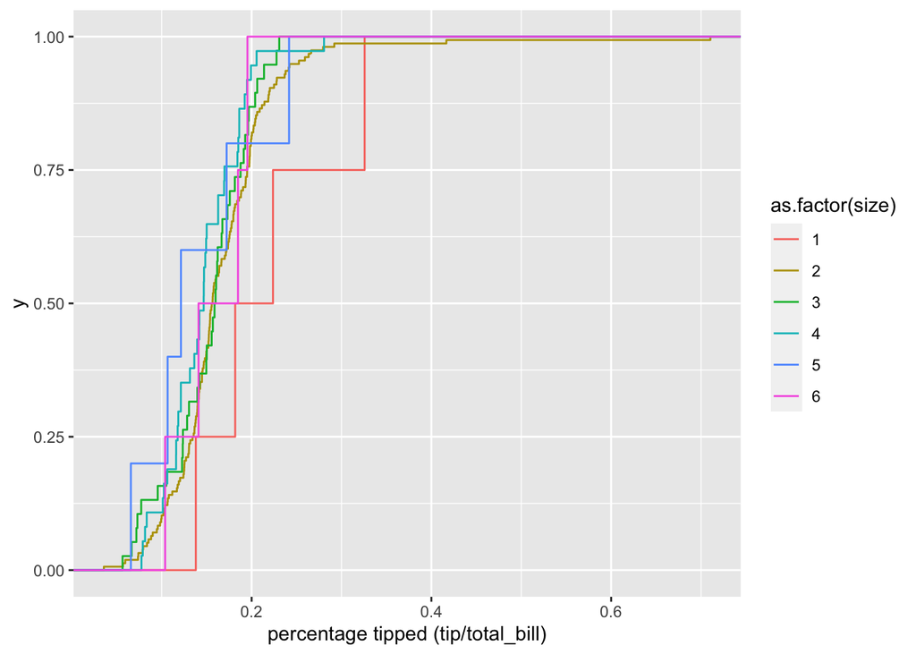

```r
ggplot(tips, aes(x = tip/total_bill)) +
    stat_ecdf(aes(color = as.factor(size))) + xlab("percentage tipped (tip/total_bill)")
```

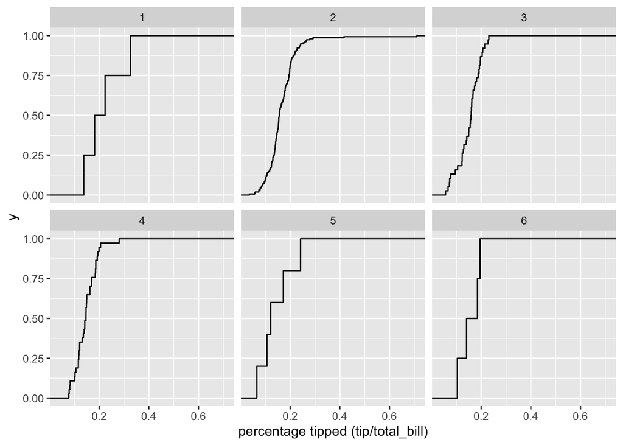

```r
ggplot(tips, aes(x = tip/total_bill)) +
    stat_ecdf() + facet_wrap(~ size) + xlab("percentage tipped (tip/total_bill)")
```

It is hard to say that there clear differences between the distributions for different party sizes or the same, since the graphs suggested that when the party size is 2,3,4, and 6, the distirbution looks similar and when the party size is 1 and 5, the distribution are different from the others.

### Question 3

I chose to use the mean because for each party size, the amount of dataset is different that choosing mode or medium wouldn’t be as accurate as using mean.

```r
agg <- aggregate(tips,by=list(tips$tip/tips$total_bill,tips$size),FUN = mean)
```

[output not shown]

[output cut: 2848 more lines]

[output not shown]

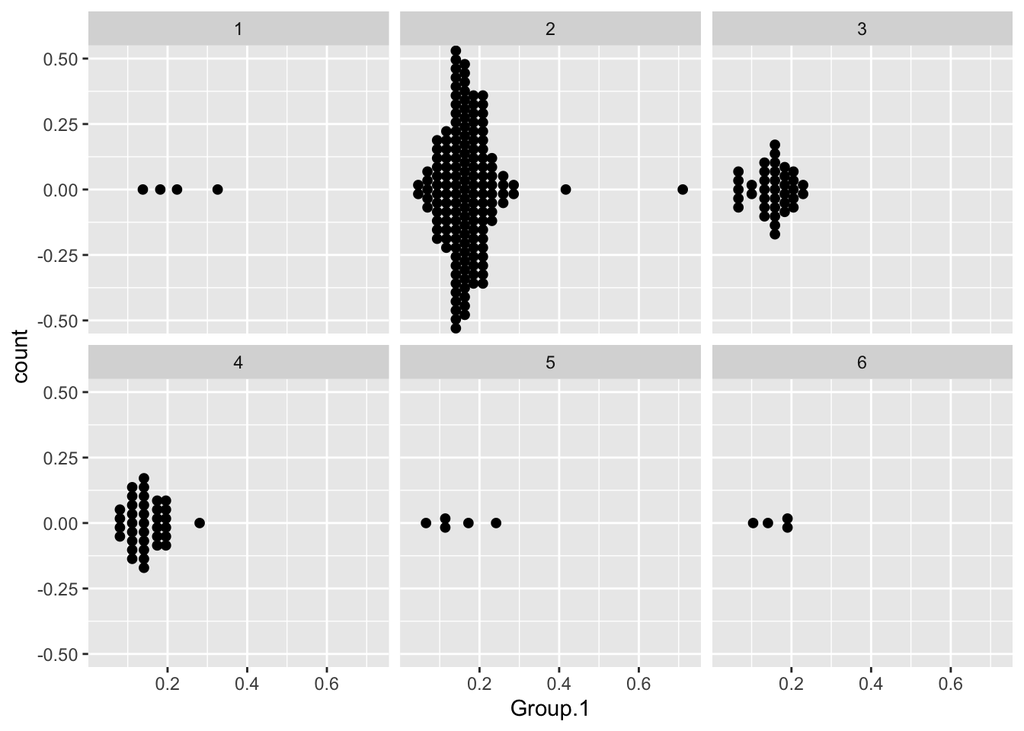

```r
#agg
ggplot(agg, aes(x=Group.1)) +
  geom_dotplot(stackdir='center') +
  facet_wrap(~ Group.2)
```

I think the plot for party size 2 looks real to me since it is the size with the most amount of data. Also, it is reasonable to think that when the party size is 2, the amount of total_bill should be in a resonable range that the cost won’t exceed too much. As the graph for size 2 shown above, only two points were away from the gathering points and obivouly that the average is small as the gathering points are located on the left side of the graph. Since the total bill amount is small, the precentage tip should be small as well.